# nNIL introgression calling: insensitivity to the intermarker recombination fraction and sensitivity to the non-informative rate

- Show All Code
- Hide All Code
- View Source

Author

Fausto Rodríguez-Zapata

Published

July 20, 2026

**NoteScope: this notebook is a *diagnostic of Holland’s calibration*, not the nilHMM analysis**

It dissects how Zhong et al. (2025) calibrated the `nnil` caller and what that chip-supervised GBS calibration (in-sample) is actually sensitive to. The clean analysis for the nilHMM paper (calibrate on **simulation**, use the **chip as an independent truth**, without mixing the two) is built separately; this notebook is the reference it is contrasted against.

Zhong et al. (2025) call introgressions in a B73 x NAM-founder nested near-isogenic line (nNIL) population with a fixed-parameter HMM (the `nnil` caller reproduced verbatim in nilHMM). Their calibration is **chip-supervised GBS calibration of the HMM**: the chip never enters the HMM as input, it supplies the reference labels the GBS calls are tuned against. Twenty-four lines were genotyped on *both* the low-coverage GBS platform and a high-quality Affymetrix chip; Holland ran the HMM on those lines’ **GBS** genotypes and picked the parameters that **minimise the disagreement between the resulting GBS calls and the chip calls** (his File_S16 grid, saved as `File_S04`). A separate chip-only fit (File_S14) produces the chip calls used as the target. He then applies the chosen parameters to the **full 888-line GBS set** to produce the published calls (File_S18): `nir` = 0.9, `germ` = 0.01, `gert` = 1e-4, `p` = 0.9, `r` = avg_r.

The methodological point to flag, because it is easy to miss, is that **the calibration is not held out**. The 24 GBS lines used to tune the parameters are a *subset* of the 888 GBS lines the tuned caller then predicts on, so the data used for calibration is reused for prediction (GBS_calib ⊂ GBS_predict). Chip-supervising the calibration on those 24 GBS lines and then predicting on the GBS set is in-sample by construction. That coupling is exactly what the clean nilHMM analysis is built to avoid: calibrate on an independent simulation, and keep the real GBS strictly for held-out evaluation.

So the object under the microscope here is that **chip-supervised GBS** calibration. The question is which parameter it actually determines:

> The recombination knob `r` (the per-adjacent-marker transition rate, i.e. the segment-length prior) is a **benign hyperparameter**. The caller’s output is insensitive to it across more than four orders of magnitude in both the chip-supervised evaluation and a `simcross` simulation of the breeding design, and it explains **0.03%** of the variance in Holland’s chip-supervised objective. The textbook map-distance heuristic $r = 2\,\mathrm{total\_cM}/(100\,N)$ is therefore more than adequate: a genetic map sets it, no chip or simulation required. The parameter that governs the caller (**97.7%** of the objective’s variance) is the emission non-informative rate `nir`, which is not a segment-length prior at all, and whose chip-supervised fit value (0.9) departs from the founder-genotype non-informative rate (~0.59, measured directly on the NAM-founder chip genotypes).

**Which data each section uses** (the point that was previously unclear; it matches the scripts):

| Section | Analysis | Data / truth |
| --- | --- | --- |
| 2 | parameter sensitivity | Holland’s **chip-supervised** grid (`File_S04`) |
| 3 | `r` sweep | **simulation** (simcross truth) *and* **chip-supervised** (caller on the 24-line GBS, scored vs the chip calls) |
| 4 | fragment sizes | A-B **simulation**; C-D **chip-supervised** |
| 5 | `nir` sweep | **chip-supervised** |

There is no chip-only sweep here; wherever a curve is labelled “chip-supervised” it means the GBS calls scored against the chip calls (the chip-supervised objective). Everything below reads the outputs of the tracked scripts in `scripts/nnil_foil/` (`01`-`08`); the heavy compute lives there. All markers are on maize **v5** (`S<chr>_<pos_v5>`).

```r
suppressMessages({
  library(data.table)
  library(ggplot2)
  library(patchwork)
  library(jsonlite)
  library(here)
})
FOIL <- here("data/nnil_foil")
theme_foil <- theme_classic(base_size = 10) +
  theme(
    text = element_text(family = "sans"),
    plot.tag = element_text(face = "bold"),
    legend.position = "top", legend.title = element_blank()
  )
col_sim <- "#0072B2"
col_chip <- "#D55E00"
col_holl <- "grey30"
col_bio <- "#009E73"
logx <- scale_x_log10(
  breaks = 10^(-6:-1),
  labels = c("1e-6", "1e-5", "1e-4", "1e-3", "1e-2", "1e-1")
)

markers <- fread(file.path(FOIL, "markers_v5.tsv"))
chip_sw <- fread(file.path(FOIL, "chip_rrate_sweep.csv"))
sim_sw <- fread(file.path(FOIL, "sim_rrate_sweep.csv"))
nir_sw <- fread(file.path(FOIL, "nir_sweep.csv"))
sens <- fread(file.path(FOIL, "holland_param_sensitivity.csv"))
ecdf_dt <- fread(file.path(FOIL, "fragsize_ecdf.csv"))
nir_ecdf <- fread(file.path(FOIL, "nir_fragsize_ecdf.csv"))
cj <- fromJSON(file.path(FOIL, "chip_calib.json"))
sj <- fromJSON(file.path(FOIL, "sim_calib.json"))
map_r <- cj$map_r # map-defined per-marker recombination fraction (native v5 map)
r_sim <- sj$rrate_sim_star
```

## 1. Reproduction setup

The nNIL population’s markers are AGPv4. To place them on a genetic map we lift them to v5 and interpolate cM from the **TeoNAM native v5 map** (the same map the `simcross` validation uses), so both sides of the foil live on one coordinate system (`scripts/nnil_foil/01_liftover_cm.R`).

```r
tot_cm <- markers[, sum(tapply(cm, chr, \(x) max(x) - min(x)))]
data.table(
  quantity = c(
    "nNIL markers lifted v4->v5", "total native cM", "chip both-platform lines",
    "chip shared markers", "sim design", "sim NILs", "map r (native v5 map)",
    "sim-selected r*"
  ),
  value = c(
    nrow(markers), round(tot_cm), cj$n_lines, cj$n_shared_markers,
    sj$design, sj$n_sim, signif(map_r, 4), signif(r_sim, 4)
  )
) |> knitr::kable()
```

| quantity | value |
| --- | --- |
| nNIL markers lifted v4->v5 | 63904 |
| total native cM | 1559 |
| chip both-platform lines | 24 |
| chip shared markers | 11310 |
| sim design | BC5S2 |
| sim NILs | 1500 |
| map r (native v5 map) | 0.0004878 |
| sim-selected r* | 0.00067 |

The total native map length (1559 cM) essentially matches Holland’s assumed 1500 cM, so the two recombination scales agree by construction. The chip calls are reproduced by porting Holland’s own File S14 pipeline and calling his File S11 HMM (`02_chip_truth.py`): chip genotypes lifted V3->V4, QC-filtered, HMM called with his chip-optimal parameters, then projected onto the nearest GBS markers. The design is **BC5S2** (five backcrosses, two selfs), which matches Holland’s HMM priors `f_1 = 1/128`, `f_2 ~= 0.0117` exactly; the `simcross` single-locus check passes (`04_sim_calibrate.R`).

## 2. Holland’s own grid: the objective is driven by `nir`, not `r`

The decisive evidence is Holland’s own full-factorial grid search over the **chip-supervised objective** (File S04, 945 combinations of `nir x germ x gert x p x r` scored by the mismatch between the GBS calls and the chip calls). A variance decomposition (`07_holland_sensitivity.R`) attributes that mismatch variance almost entirely to `nir`:

```r
sens[, .(
  parameter = param, `variance share` = sprintf("%.1f%%", 100 * var_share),
  `marginal effect (x vs r)` = round(rel_to_best_r, 1)
)][order(-`variance share`)] |>
  knitr::kable()
```

| parameter | variance share | marginal effect (x vs r) |
| --- | --- | --- |
| nir | 97.7% | 58.7 |
| germ | 0.5% | 3.9 |
| p | 0.4% | 3.8 |
| r | 0.0% | 1.0 |
| gert | 0.0% | 0.7 |

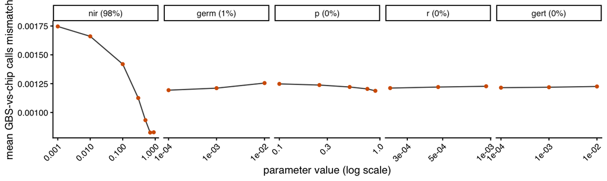

Figure 1: Holland’s full-factorial grid (File S04): the GBS-vs-chip calls mismatch is driven almost entirely by the emission non-informative rate nir, not by the recombination fraction r. Each panel plots the mean mismatch, marginalised over the other parameters, against one parameter (log x); the percentage in each strip label is that parameter’s share of the mismatch variance.

```r
d4 <- fread(here("agent/nNIL/File_S04.nNIL_gbs_vs_chip_data_HMMgridSearch.csv"))
params <- c("nir", "germ", "gert", "p", "r")
plt <- rbindlist(lapply(params, function(pp) {
  m <- d4[, .(mm = mean(mismatchMean)), by = c(pp)]
  setnames(m, pp, "level")
  m[, param := pp][]
}))
plt[, param := factor(param,
  levels = sens[order(-var_share)]$param,
  labels = sprintf("%s (%.0f%%)", sens[order(-var_share)]$param, 100 * sens[order(-var_share)]$var_share)
)]
ggplot(plt, aes(level, mm)) +
  geom_line(linewidth = 0.5, colour = "grey30") +
  geom_point(size = 1.2, colour = col_chip) +
  facet_wrap(~param, scales = "free_x", nrow = 1) +
  scale_x_log10() +
  labs(x = "parameter value (log scale)", y = "mean GBS-vs-chip calls mismatch") +
  theme_foil +
  theme(axis.text.x = element_text(angle = 45, hjust = 1))
```

`nir` explains **97.7%** of the variance; `r` explains **0.03%**. The 3-point `r` grid Holland used sits entirely inside the flat basin we map in Section 3, so of course it moved nothing; `nir`, swept across three orders of magnitude, moved everything. The rest of the notebook takes each knob in turn: `r` (Section 3, the fragment sizes in Section 4) and `nir` (Section 5).

## 3. The fit is insensitive to r

**What is `r`?** In this HMM `r` is the **expected recombination *fraction* between two adjacent markers**: the probability that the ancestry state switches across one marker interval (the off-diagonal transition mass; self-stay $= 1 - r$). It is *not* a per-bp or per-cM rate (it carries no length units, it is per-marker-interval), and it is *not* realized recombination in the population; it is a prior/hyperparameter of the caller. The **“map `r`”** is one specific value of it, the mean the genetic map implies: $r_\text{map} = 2\,L/(100\,N)$, with $L$ the total map length in cM (native TeoNAM v5, 1559 cM) and $N$ the number of markers. It folds in two approximations. (i) $L/N$ cM per interval becomes a recombination fraction via $r \approx \mathrm{cM}/100$, the small-distance (asymptotic) limit in which the map function is linear and recombination fraction meets genetic distance as the interval shrinks. (ii) The factor 2 is the map expansion of an inbred, RIL-like pedigree: recombination accumulates over the roughly two effective meioses of the backcross-plus-selfing route to homozygosity, so per-interval recombination is about double the single-meiosis value (Haldane and Waddington 1931, *Genetics* 16(4):357-374, doi:10.1093/genetics/16.4.357) – the doubling Holland invokes in his code. Here $r_\text{map} = 4.88\times10^{-4}$. This is **not “Holland’s `r`”**: Holland did not tune `r` against the chip (as Section 2 shows, the chip objective is flat in `r`); he plugged in this map heuristic, and his chip calibration determined `nir` instead.

We sweep the caller’s `r` over `[1e-6, 1e-1]` two ways: on the **real 24-line GBS scored against the chip calls** (the chip-supervised objective, `03_chip_calibrate.R`), and on a **dense `simcross` simulation against its own truth** (BC5S2, 1500 NILs, `04_sim_calibrate.R`), scoring **donor-fragment DSC** (Dice-Sørensen coefficient, the reciprocal-overlap match of donor blocks). The chip-supervised side additionally reports Holland’s own objective (GBS-vs-chip calls mismatch).

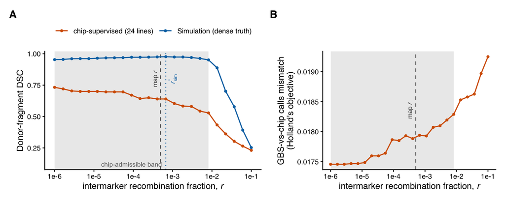

Figure 2: The intermarker recombination fraction r is a benign hyperparameter. A, donor-fragment DSC versus r for the dense simcross simulation (blue) and the chip-supervised calibration on the 24 both-platform lines (orange); the shaded band is the chip-admissible range where Holland’s mismatch stays within 5% of its minimum. B, Holland’s objective (GBS-vs-chip calls mismatch) versus r, near-flat across four orders of magnitude. Dashed line, the map-defined r; dotted line, the simulation-optimal r.

```r
band <- cj$mismatch_plateau
cur <- rbind(
  data.table(rrate = sim_sw$rrate, dice = sim_sw$donor_frag_dice, src = "Simulation (dense truth)"),
  data.table(rrate = chip_sw$rrate, dice = chip_sw$donor_frag_dice, src = "chip-supervised (24 lines)")
)
xlab_r <- expression("intermarker recombination fraction, " * italic(r))
pA <- ggplot(cur, aes(rrate, dice, colour = src)) +
  annotate("rect", xmin = band[1], xmax = band[2], ymin = -Inf, ymax = Inf, fill = "grey85", alpha = 0.5) +
  geom_vline(xintercept = map_r, linetype = "dashed", colour = col_holl, linewidth = 0.4) +
  geom_vline(xintercept = r_sim, linetype = "dotted", colour = col_sim, linewidth = 0.5) +
  geom_line(linewidth = 0.6) +
  geom_point(size = 1) +
  scale_colour_manual(values = c("Simulation (dense truth)" = col_sim, "chip-supervised (24 lines)" = col_chip)) +
  logx +
  labs(x = xlab_r, y = "Donor-fragment DSC", tag = "A") +
  annotate("text",
    x = map_r, y = 0.8, label = "map~italic(r)", parse = TRUE,
    angle = 90, vjust = -0.4, hjust = 0.5, size = 2.6, colour = col_holl
  ) +
  annotate("text",
    x = r_sim, y = 0.8, label = "italic(r)[sim]^'*'", parse = TRUE,
    angle = 90, vjust = 1.3, hjust = 0.5, size = 2.6, colour = col_sim
  ) +
  annotate("text", x = sqrt(band[1] * band[2]), y = 0.12, label = "chip-admissible band", size = 2.6, colour = "grey40") +
  theme_foil
pB <- ggplot(chip_sw, aes(rrate, holland_mismatch)) +
  annotate("rect", xmin = band[1], xmax = band[2], ymin = -Inf, ymax = Inf, fill = "grey85", alpha = 0.5) +
  geom_vline(xintercept = map_r, linetype = "dashed", colour = col_holl, linewidth = 0.4) +
  geom_line(linewidth = 0.6, colour = col_chip) +
  geom_point(size = 1, colour = col_chip) +
  logx +
  labs(x = xlab_r, y = "GBS-vs-chip calls mismatch\n(Holland's objective)", tag = "B") +
  annotate("text",
    x = map_r, y = mean(range(chip_sw$holland_mismatch)), label = "map~italic(r)",
    parse = TRUE, angle = 90, vjust = -0.4, hjust = 0.5, size = 2.6, colour = col_holl
  ) +
  theme_foil +
  theme(legend.position = "none")
pA + pB + plot_layout(widths = c(1.25, 1))
```

The insensitivity is clearest in the **DSC curve of the dense simulation** (**A**, blue): it is a broad plateau, near-optimal from `1e-6` up to ~`1e-2` before it collapses. That plateau *is* the safe basin. The chip metrics do not pin `r` down either, but neither is a plateau: the chip DSC (**A**, orange) declines monotonically and Holland’s marker mismatch (**B**) rises monotonically, both only weakly – the mismatch stays within 5% of its minimum across [1e-06, 8e-03] (the shaded band), so it barely prefers any `r`. The simulation’s interior DSC optimum, `r_sim* =` $6.7\times10^{-4}$, is close to the map value `map r =` $4.88\times10^{-4}$, but given the plateau that near-match is almost trivial; the map value sits comfortably inside the basin regardless. Contrast this with `nir`, the orthogonal slice through the same operating point, in Section 5.

## 4. The fragment-size distribution is recovered across the whole basin

The same failure mode, over-fragmentation, is what both knobs eventually cause, so we look at it directly through the donor-fragment-size distribution. The top row sweeps `r` (`06_fragsize_figure.R`); the bottom row sweeps `nir` at the map `r` (`08_nir_sweep.R`).

**A-B (varying `r`, on the simulation).** KS(called, simcross truth) is low and flat below ~`1e-2` and blows up only above it (**A**); at the map `r`, the DSC r*, and the KS r* the ECDFs are indistinguishable from truth (**B**), and only a clearly-broken `r` (2.2e-2) peels off toward small fragments.

**C-D (varying `nir` at the map `r`, on the real 24-line GBS vs the chip calls).** KS(called, chip) falls monotonically as `nir` rises (**C**), and the ECDF marches from badly over-fragmented at low `nir` up to the chip calls by `nir` ~0.9 (**D**; ~1,400 donor blocks at `nir` 0.1 down to ~110 at 0.9 versus ~90 in the truth).

Two things to read carefully. First, **the data sources differ by row**: we have a dense ground truth only in simulation (A-B); the real nNIL offers only the sparse chip subset (C-D), so its “truth” is the chip, not simcross. Second, **only C-D show a spike of ~100 bp (1e-4 Mb) fragments** – because the GBS markers are densely clustered (median spacing 28 bp; ~65% of gaps under 200 bp) and the real reads carry fine-scale noise, so isolated/paired spurious ALT calls become tiny two-marker donor blocks. The simulation (A-B) generates coherent donor markers and so produces essentially none of these (its smallest blocks are ~0.03 Mb); it does not reproduce the real GBS’s fine-scale clustering/noise. That artifact is present at every `nir` in D (even 0.9 leaves ~21% of blocks under 1e-3 Mb), which is why the KS in C plateaus rather than reaching 0.

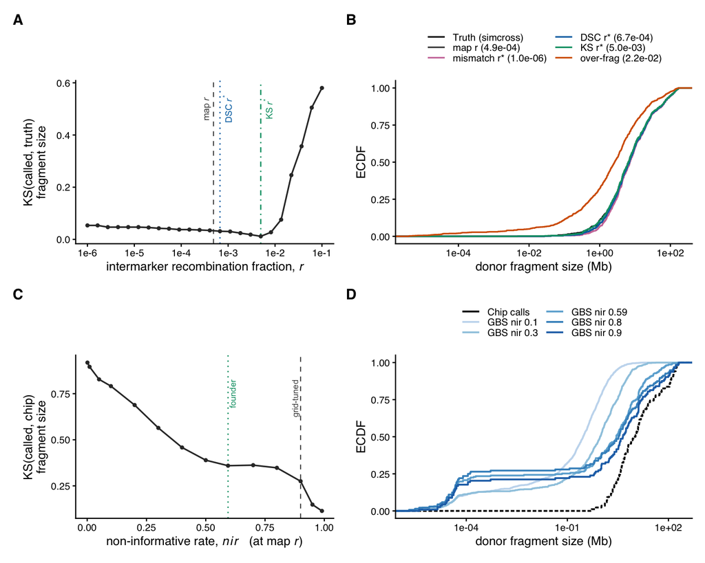

Figure 3: Donor-fragment-size distributions across the r and nir sweeps. Top row (A, B) varies r on the simulation against the dense simcross truth; bottom row (C, D) varies nir at the map-defined r on the real 24-line GBS against the chip calls. A, KS distance between called and true fragment sizes versus r. B, fragment-size ECDFs at r reference points, indistinguishable from truth until r is clearly broken. C, KS distance versus nir. D, fragment-size ECDFs for a ladder of GBS-caller nir values (blue ramp) against the chip calls (black dashed); the distribution recovers from badly over-fragmented at low nir up to the chip calls by nir about 0.9. The spike near 1e-4 Mb in D is a real-GBS artifact absent from the clean simulation.

```r
r_dice <- sim_sw$rrate[which.max(sim_sw$donor_frag_dice)]
r_ks <- sim_sw$rrate[which.min(sim_sw$ks_fragsize)]
pK <- ggplot(sim_sw, aes(rrate, ks_fragsize)) +
  geom_vline(xintercept = map_r, linetype = "dashed", colour = col_holl, linewidth = 0.4) +
  geom_vline(xintercept = r_dice, linetype = "dotted", colour = col_sim, linewidth = 0.5) +
  geom_vline(xintercept = r_ks, linetype = "dotdash", colour = col_bio, linewidth = 0.5) +
  geom_line(linewidth = 0.6, colour = "grey20") +
  geom_point(size = 1, colour = "grey20") +
  logx +
  labs(x = xlab_r, y = "KS(called, truth)\nfragment size", tag = "A") +
  annotate("text",
    x = map_r, y = 0.5, label = "map~italic(r)",
    parse = TRUE, angle = 90, vjust = -0.4, hjust = 0.5, size = 2.6, colour = col_holl
  ) +
  annotate("text",
    x = r_dice, y = 0.5, label = "DSC~italic(r)^'*'",
    parse = TRUE, angle = 90, vjust = 1.3, hjust = 0.5, size = 2.6, colour = col_sim
  ) +
  annotate("text",
    x = r_ks, y = 0.5, label = "KS~italic(r)^'*'",
    parse = TRUE, angle = 90, vjust = 1.3, hjust = 0.5, size = 2.6, colour = col_bio
  ) +
  theme_foil
# Okabe-Ito palette keyed by series name (matches 06_fragsize_figure.R)
.lv <- unique(as.character(ecdf_dt$series))
.key <- c("Truth", "^map r", "mismatch", "DSC", "KS", "over-frag")
.lv <- .lv[order(vapply(.lv, function(s) which(vapply(.key, grepl, logical(1), x = s))[1], integer(1)))]
ecdf_dt[, series := factor(series, levels = .lv)]
pal <- vapply(.lv, function(s) {
  if (grepl("Truth", s)) {
    "black"
  } else if (grepl("^map r", s)) {
    col_holl
  } else if (grepl("mismatch", s)) {
    "#CC79A7"
  } else if (grepl("DSC", s)) {
    col_sim
  } else if (grepl("KS", s)) col_bio else col_chip
}, character(1))
pE <- ggplot(ecdf_dt, aes(size_mb, colour = series)) +
  stat_ecdf(linewidth = 0.6) +
  scale_x_log10() +
  scale_colour_manual(values = setNames(pal, .lv)) +
  labs(x = "donor fragment size (Mb)", y = "ECDF", tag = "B") +
  theme_foil +
  theme(
    legend.key.height = unit(0.4, "lines"), legend.key.spacing.y = unit(1, "pt"),
    legend.text = element_text(size = 8)
  ) +
  guides(colour = guide_legend(nrow = 3))

# Panels C-D: the same fragment-size view holding r at the map value and varying
# nir instead. NOTE the data source differs: A-B are the SIMULATION (simcross
# truth); C-D are the REAL 24-line GBS vs the chip calls (we have dense truth only
# in simulation; the real nNIL has only the sparse chip subset).
pKn <- ggplot(nir_sw, aes(nir, frag_ks)) +
  geom_vline(xintercept = 0.9, linetype = "dashed", colour = col_holl, linewidth = 0.4) +
  geom_vline(xintercept = 0.594, linetype = "dotted", colour = col_bio, linewidth = 0.5) +
  geom_line(linewidth = 0.6, colour = "grey20") +
  geom_point(size = 1, colour = "grey20") +
  labs(
    x = expression("non-informative rate, " * italic(nir) * "   (at map " * italic(r) * ")"),
    y = "KS(called, chip)\nfragment size", tag = "C"
  ) +
  annotate("text",
    x = 0.9, y = max(nir_sw$frag_ks) * 0.9, label = "grid-tuned",
    angle = 90, vjust = -0.4, hjust = 1, size = 2.4, colour = col_holl
  ) +
  annotate("text",
    x = 0.594, y = max(nir_sw$frag_ks) * 0.9, label = "founder",
    angle = 90, vjust = 1.3, hjust = 1, size = 2.4, colour = col_bio
  ) +
  theme_foil
nir_ecdf[, series := factor(series,
  levels = c("Chip calls", "GBS nir 0.1", "GBS nir 0.3", "GBS nir 0.59", "GBS nir 0.8", "GBS nir 0.9")
)]
# chip calls = black dashed (distinct from the darkest blue); GBS nir = a light->medium
# blue ramp that never approaches black, so GBS nir 0.9 stays visually separate.
pal_n <- c(
  "Chip calls" = "black", "GBS nir 0.1" = "#c6dbef", "GBS nir 0.3" = "#9ecae1",
  "GBS nir 0.59" = "#6baed6", "GBS nir 0.8" = "#4292c6", "GBS nir 0.9" = "#2171b5"
)
pEn <- ggplot(nir_ecdf, aes(size_mb, colour = series, linetype = series == "Chip calls")) +
  stat_ecdf(linewidth = 0.7) +
  scale_x_log10() +
  scale_colour_manual(values = pal_n) +
  scale_linetype_manual(values = c(`FALSE` = "solid", `TRUE` = "21"), guide = "none") +
  labs(x = "donor fragment size (Mb)", y = "ECDF", tag = "D") +
  theme_foil +
  theme(
    legend.key.height = unit(0.4, "lines"), legend.key.spacing.y = unit(1, "pt"),
    legend.text = element_text(size = 8)
  ) +
  guides(colour = guide_legend(nrow = 3))
pK + pE + pKn + pEn + plot_layout(ncol = 2, widths = c(1, 1.15))
```

## 5. `nir` at the map-defined `r`: the grid-tuned 0.9 is the chip-supervised optimum

Holding `r` at the map value and sweeping `nir` on the **real 24-line GBS scored against the chip** (`08_nir_sweep.R`). **Read the three panels by direction, not by slope:** two are *error* metrics that should fall (marker mismatch and fragment-size KS: lower is better) and one is an *agreement* metric that should rise (donor-fragment DSC: higher is better). All three do exactly that as `nir` increases, so DSC climbing is the **same verdict** as mismatch and KS dropping, not the opposite – **every metric improves with higher `nir`**. There is no disagreement: mismatch and DSC are both best around **`nir ~= 0.9-0.95`** (mismatch bottoms at 0.95 and turns back up by 0.99; DSC peaks at 0.95), and KS has no interior optimum, improving monotonically to 0.99. So Holland’s **grid-tuned `nir = 0.9`** sits at or just below the chip-supervised optimum, and the **founder-genotype `nir ~= 0.59`** (f0 on the NAM-founder chip genotypes, `agent/nnil_foil_estimate_nir.py`) is well down every curve (at 0.59 the caller recovers DSC ~0.34 versus ~0.64 at 0.9).

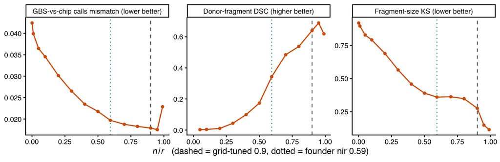

Figure 4: nir sweep at the map-defined r, on the real 24-line GBS scored against the chip calls. The three metrics versus the caller’s nir all improve as nir rises: GBS-vs-chip calls mismatch and fragment-size KS fall (lower is better) and donor-fragment DSC rises (higher is better). Dashed line, Holland’s grid-tuned nir = 0.9; dotted line, the founder-genotype nir about 0.59 (f0 measured on the NAM-founder chip genotypes).

```r
long <- rbind(
  data.table(nir = nir_sw$nir, val = nir_sw$marker_mismatch, metric = "GBS-vs-chip calls mismatch"),
  data.table(nir = nir_sw$nir, val = nir_sw$donor_frag_dice, metric = "Donor-fragment DSC"),
  data.table(nir = nir_sw$nir, val = nir_sw$frag_ks, metric = "Fragment-size KS")
)
long[, metric := factor(metric,
  levels = c("GBS-vs-chip calls mismatch", "Donor-fragment DSC", "Fragment-size KS"),
  labels = c(
    "GBS-vs-chip calls mismatch (lower better)", "Donor-fragment DSC (higher better)",
    "Fragment-size KS (lower better)"
  )
)]
ggplot(long, aes(nir, val)) +
  geom_vline(xintercept = 0.9, linetype = "dashed", colour = col_holl, linewidth = 0.4) +
  geom_vline(xintercept = 0.594, linetype = "dotted", colour = col_bio, linewidth = 0.5) +
  geom_line(linewidth = 0.6, colour = col_chip) +
  geom_point(size = 1.2, colour = col_chip) +
  facet_wrap(~metric, scales = "free_y", nrow = 1) +
  labs(x = expression(italic(nir) * "   (dashed = grid-tuned 0.9, dotted = founder nir 0.59)"), y = NULL) +
  theme_foil
```

Why does raising `nir` improve *every* metric, and why does the best value exceed the founder-genotype rate? `nir` is the caller’s assumed rate at which a donor haplotype still shows the REF (B73) allele. At **low `nir`** the caller trusts each marker literally: it calls donor only at the sparse ALT markers and reverts to REF across the intervening (non-informative) REF markers, **shattering each true donor tract into many tiny blocks** (~1,400 called blocks versus ~90 in the truth). DSC is near 0 because those fragments do not reciprocally overlap the true blocks, KS is far from truth, and the donor part of the mismatch is inflated. Raising `nir` tells the caller to hold the donor state across the REF markers, merging the fragments back into the true tracts (down to ~110 blocks at `nir` 0.9) – which is why all three metrics improve together. The caller therefore *needs* a high `nir`, higher even than the founder value: 0.59 already under-calls (DSC only ~0.34), so the data prefer ~0.9. That extra headroom (0.9 vs 0.59) is `nir` doing double duty – it absorbs the additional REF-bias that low-coverage GBS adds (dropout, allele miscalls) on top of the founder informativeness. The clean “`nir` = donor-founder match rate” reading does not survive the fit.

The fragment-size consequence of sweeping `nir` (over-fragmentation at low `nir`, recovery by ~0.9) is shown alongside its `r` counterpart in Section 4, panels C-D.

## Conclusion

- **`r` needs no calibration.** The caller’s output is insensitive to it over four-plus orders of magnitude (chip and sim), it explains 0.03% of Holland’s objective, and the map-distance heuristic lands in the middle of the safe basin. A genetic map is sufficient; neither a chip nor a simulation is required to set it.
- **The calibration signal is in the emission `nir`**, which the chip-supervised fit pins sharply to a grid-tuned ~0.9. That value is not the founder-match non-informative rate (~0.59); the chip-supervised objective prefers 0.9 because `nir` also absorbs the GBS data quality that separates the two platforms.
- **Because `nir` absorbs data quality, it cannot be read off the reference panel.** The founder-genotype estimate (~0.59) fits the chip worse than the tuned 0.9, so “estimate `nir` from the donor-founder match” is *not* a safe shortcut. `nir` is the real calibration burden: it needs tuning against truth (a chip or a simulation), or an emission model that separates founder informativeness from data quality. `r`, by contrast, comes free from the map. The division of labour is the point – calibrate the emission, not the recombination knob.

Reproduce end to end: `scripts/nnil_foil/01_liftover_cm.R` -> `02_chip_truth.py` -> `03_chip_calibrate.R` -> `04_sim_calibrate.R` -> `05_foil_figure.R` -> `06_fragsize_figure.R` -> `07_holland_sensitivity.R` -> `08_nir_sweep.R`.